# Risk Factor Analysis

## Outcome Variable

**Outcome Variable:** wasted

## Predictor Variables

**Intervention Variable:** exclfeed3

**Adjustment Set:**

- arm
- sex
- brthmon
- W_mage
- meducyrs
- feducyrs
- hhwealth_quart
- hfoodsec
- W_mhtcm
- W_mwtkg
- W_mbmi
- vagbrth
- W_gagebrth
- W_birthwt
- W_birthlen
- W_nrooms
- W_nchldlt5
- month
- W_parity
- impfloor
- impsan
- safeh20
- delta_W_mage
- delta_meducyrs
- delta_feducyrs
- delta_hhwealth_quart
- delta_hfoodsec
- delta_W_mhtcm
- delta_W_mwtkg
- delta_W_mbmi
- delta_vagbrth
- delta_W_gagebrth
- delta_W_birthwt
- delta_W_birthlen
- delta_W_nrooms
- delta_W_nchldlt5
- delta_month
- delta_W_parity
- delta_impfloor
- delta_impsan
- delta_safeh20

## Stratifying Variables

The analysis was stratified on these variable(s):

- agecat
- studyid
- country

## Data Summary

| agecat | studyid | country | exclfeed3 | wasted | n_cell | n |
| --- | --- | --- | --- | --- | --- | --- |
| Birth | ki0047075b-MAL-ED | BANGLADESH | 1 | 0 | 109 | 202 |
| Birth | ki0047075b-MAL-ED | BANGLADESH | 1 | 1 | 21 | 202 |
| Birth | ki0047075b-MAL-ED | BANGLADESH | 0 | 0 | 60 | 202 |
| Birth | ki0047075b-MAL-ED | BANGLADESH | 0 | 1 | 12 | 202 |
| Birth | ki0047075b-MAL-ED | BRAZIL | 1 | 0 | 11 | 55 |
| Birth | ki0047075b-MAL-ED | BRAZIL | 1 | 1 | 0 | 55 |
| Birth | ki0047075b-MAL-ED | BRAZIL | 0 | 0 | 43 | 55 |
| Birth | ki0047075b-MAL-ED | BRAZIL | 0 | 1 | 1 | 55 |
| Birth | ki0047075b-MAL-ED | INDIA | 1 | 0 | 19 | 39 |
| Birth | ki0047075b-MAL-ED | INDIA | 1 | 1 | 3 | 39 |
| Birth | ki0047075b-MAL-ED | INDIA | 0 | 0 | 15 | 39 |
| Birth | ki0047075b-MAL-ED | INDIA | 0 | 1 | 2 | 39 |
| Birth | ki0047075b-MAL-ED | NEPAL | 1 | 0 | 8 | 25 |
| Birth | ki0047075b-MAL-ED | NEPAL | 1 | 1 | 0 | 25 |
| Birth | ki0047075b-MAL-ED | NEPAL | 0 | 0 | 15 | 25 |
| Birth | ki0047075b-MAL-ED | NEPAL | 0 | 1 | 2 | 25 |
| Birth | ki0047075b-MAL-ED | PERU | 1 | 0 | 47 | 218 |
| Birth | ki0047075b-MAL-ED | PERU | 1 | 1 | 0 | 218 |
| Birth | ki0047075b-MAL-ED | PERU | 0 | 0 | 166 | 218 |
| Birth | ki0047075b-MAL-ED | PERU | 0 | 1 | 5 | 218 |
| Birth | ki0047075b-MAL-ED | SOUTH AFRICA | 1 | 0 | 12 | 99 |
| Birth | ki0047075b-MAL-ED | SOUTH AFRICA | 1 | 1 | 0 | 99 |
| Birth | ki0047075b-MAL-ED | SOUTH AFRICA | 0 | 0 | 78 | 99 |
| Birth | ki0047075b-MAL-ED | SOUTH AFRICA | 0 | 1 | 9 | 99 |
| Birth | ki0047075b-MAL-ED | TANZANIA, UNITED REPUBLIC OF | 1 | 0 | 15 | 95 |
| Birth | ki0047075b-MAL-ED | TANZANIA, UNITED REPUBLIC OF | 1 | 1 | 0 | 95 |
| Birth | ki0047075b-MAL-ED | TANZANIA, UNITED REPUBLIC OF | 0 | 0 | 79 | 95 |
| Birth | ki0047075b-MAL-ED | TANZANIA, UNITED REPUBLIC OF | 0 | 1 | 1 | 95 |
| Birth | ki1000108-CMC-V-BCS-2002 | INDIA | 1 | 0 | 4 | 4 |
| Birth | ki1000108-CMC-V-BCS-2002 | INDIA | 1 | 1 | 0 | 4 |

[output cut: 158 more lines]

The following strata were considered:

- agecat: 24 months, studyid: ki0047075b-MAL-ED, country: BANGLADESH
- agecat: 24 months, studyid: ki0047075b-MAL-ED, country: BRAZIL
- agecat: 24 months, studyid: ki0047075b-MAL-ED, country: INDIA
- agecat: 24 months, studyid: ki0047075b-MAL-ED, country: NEPAL
- agecat: 24 months, studyid: ki0047075b-MAL-ED, country: PERU
- agecat: 24 months, studyid: ki0047075b-MAL-ED, country: SOUTH AFRICA
- agecat: 24 months, studyid: ki0047075b-MAL-ED, country: TANZANIA, UNITED REPUBLIC OF
- agecat: 24 months, studyid: ki1000108-CMC-V-BCS-2002, country: INDIA
- agecat: 24 months, studyid: ki1000108-IRC, country: INDIA
- agecat: 24 months, studyid: ki1000109-EE, country: PAKISTAN
- agecat: 24 months, studyid: ki1017093b-PROVIDE, country: BANGLADESH
- agecat: 24 months, studyid: ki1101329-Keneba, country: GAMBIA
- agecat: 24 months, studyid: ki1113344-GMS-Nepal, country: NEPAL
- agecat: 24 months, studyid: kiGH5241-JiVitA-3, country: BANGLADESH
- agecat: 24 months, studyid: kiGH5241-JiVitA-4, country: BANGLADESH
- agecat: 6 months, studyid: ki0047075b-MAL-ED, country: BANGLADESH
- agecat: 6 months, studyid: ki0047075b-MAL-ED, country: BRAZIL
- agecat: 6 months, studyid: ki0047075b-MAL-ED, country: INDIA
- agecat: 6 months, studyid: ki0047075b-MAL-ED, country: NEPAL
- agecat: 6 months, studyid: ki0047075b-MAL-ED, country: PERU
- agecat: 6 months, studyid: ki0047075b-MAL-ED, country: SOUTH AFRICA
- agecat: 6 months, studyid: ki0047075b-MAL-ED, country: TANZANIA, UNITED REPUBLIC OF
- agecat: 6 months, studyid: ki1000108-CMC-V-BCS-2002, country: INDIA
- agecat: 6 months, studyid: ki1000108-IRC, country: INDIA
- agecat: 6 months, studyid: ki1000109-EE, country: PAKISTAN
- agecat: 6 months, studyid: ki1000304b-SAS-CompFeed, country: INDIA
- agecat: 6 months, studyid: ki1017093b-PROVIDE, country: BANGLADESH
- agecat: 6 months, studyid: ki1101329-Keneba, country: GAMBIA
- agecat: 6 months, studyid: ki1113344-GMS-Nepal, country: NEPAL
- agecat: 6 months, studyid: kiGH5241-JiVitA-3, country: BANGLADESH
- agecat: 6 months, studyid: kiGH5241-JiVitA-4, country: BANGLADESH
- agecat: Birth, studyid: ki0047075b-MAL-ED, country: BANGLADESH
- agecat: Birth, studyid: ki0047075b-MAL-ED, country: BRAZIL
- agecat: Birth, studyid: ki0047075b-MAL-ED, country: INDIA
- agecat: Birth, studyid: ki0047075b-MAL-ED, country: NEPAL
- agecat: Birth, studyid: ki0047075b-MAL-ED, country: PERU
- agecat: Birth, studyid: ki0047075b-MAL-ED, country: SOUTH AFRICA
- agecat: Birth, studyid: ki0047075b-MAL-ED, country: TANZANIA, UNITED REPUBLIC OF
- agecat: Birth, studyid: ki1000108-CMC-V-BCS-2002, country: INDIA
- agecat: Birth, studyid: ki1000108-IRC, country: INDIA
- agecat: Birth, studyid: ki1000109-EE, country: PAKISTAN
- agecat: Birth, studyid: ki1000304b-SAS-CompFeed, country: INDIA
- agecat: Birth, studyid: ki1017093b-PROVIDE, country: BANGLADESH
- agecat: Birth, studyid: ki1101329-Keneba, country: GAMBIA
- agecat: Birth, studyid: ki1113344-GMS-Nepal, country: NEPAL
- agecat: Birth, studyid: kiGH5241-JiVitA-3, country: BANGLADESH
- agecat: Birth, studyid: kiGH5241-JiVitA-4, country: BANGLADESH

### Dropped Strata

Some strata were dropped due to rare outcomes:

- agecat: Birth, studyid: ki0047075b-MAL-ED, country: BRAZIL
- agecat: Birth, studyid: ki0047075b-MAL-ED, country: INDIA
- agecat: Birth, studyid: ki0047075b-MAL-ED, country: NEPAL
- agecat: Birth, studyid: ki0047075b-MAL-ED, country: PERU
- agecat: Birth, studyid: ki0047075b-MAL-ED, country: SOUTH AFRICA
- agecat: Birth, studyid: ki0047075b-MAL-ED, country: TANZANIA, UNITED REPUBLIC OF
- agecat: Birth, studyid: ki1000108-CMC-V-BCS-2002, country: INDIA
- agecat: Birth, studyid: ki1000108-IRC, country: INDIA
- agecat: Birth, studyid: ki1000109-EE, country: PAKISTAN
- agecat: Birth, studyid: ki1000304b-SAS-CompFeed, country: INDIA
- agecat: Birth, studyid: kiGH5241-JiVitA-4, country: BANGLADESH
- agecat: 6 months, studyid: ki0047075b-MAL-ED, country: BANGLADESH
- agecat: 6 months, studyid: ki0047075b-MAL-ED, country: BRAZIL
- agecat: 6 months, studyid: ki0047075b-MAL-ED, country: NEPAL
- agecat: 6 months, studyid: ki0047075b-MAL-ED, country: PERU
- agecat: 6 months, studyid: ki0047075b-MAL-ED, country: SOUTH AFRICA
- agecat: 6 months, studyid: ki0047075b-MAL-ED, country: TANZANIA, UNITED REPUBLIC OF
- agecat: 6 months, studyid: ki1000108-CMC-V-BCS-2002, country: INDIA
- agecat: 6 months, studyid: ki1000108-IRC, country: INDIA
- agecat: 6 months, studyid: ki1000109-EE, country: PAKISTAN
- agecat: 6 months, studyid: ki1000304b-SAS-CompFeed, country: INDIA
- agecat: 6 months, studyid: kiGH5241-JiVitA-4, country: BANGLADESH
- agecat: 24 months, studyid: ki0047075b-MAL-ED, country: BANGLADESH
- agecat: 24 months, studyid: ki0047075b-MAL-ED, country: BRAZIL
- agecat: 24 months, studyid: ki0047075b-MAL-ED, country: NEPAL
- agecat: 24 months, studyid: ki0047075b-MAL-ED, country: PERU
- agecat: 24 months, studyid: ki0047075b-MAL-ED, country: SOUTH AFRICA
- agecat: 24 months, studyid: ki0047075b-MAL-ED, country: TANZANIA, UNITED REPUBLIC OF
- agecat: 24 months, studyid: ki1000108-CMC-V-BCS-2002, country: INDIA
- agecat: 24 months, studyid: ki1000108-IRC, country: INDIA
- agecat: 24 months, studyid: ki1000109-EE, country: PAKISTAN
- agecat: 24 months, studyid: kiGH5241-JiVitA-4, country: BANGLADESH

## Methods Detail

We’re interested in the causal parameters $E[Y_a]$ for all values of $a \in \mathcal{A}$. These parameters represent the mean outcome if, possibly contrary to fact, we intervened to set all units to have $A=a$. Under the randomization and positivity assumptions, these are identified by the statistical parameters $\psi_a=E_W[E_{Y|A,W}(Y|A=a,W)]$. In addition, we’re interested in the mean of $Y$, $E[Y]$ under no intervention (the observed mean). We will estimate these parameters by using SuperLearner to fit the relevant likelihood factors – $E_{Y|A,W}(Y|A=a,W)$ and $p(A=a|W)$, and then updating our likelihood fit using a joint TMLE.

For unadjusted analyses ($W=\{\}$), initial likelihoods were estimated using Lrnr_glm to estimate the simple $E(Y|A)$ and Lrnr_mean to estimate $p(A)$. For adjusted analyses, a small library containing Lrnr_glmnet, Lrnr_xgboost, and Lrnr_mean was used.

Having estimated these parameters, we will then use the delta method to estimate relative risks and attributable risks relative to a prespecified baseline level of $A$.

# Results Detail

## Results Plots

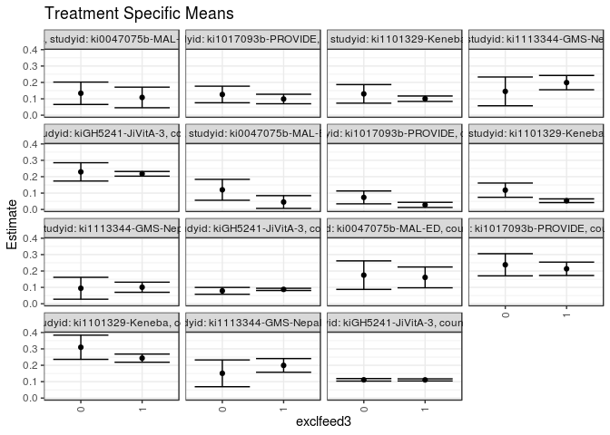

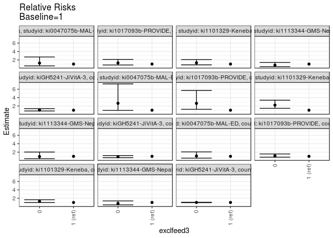

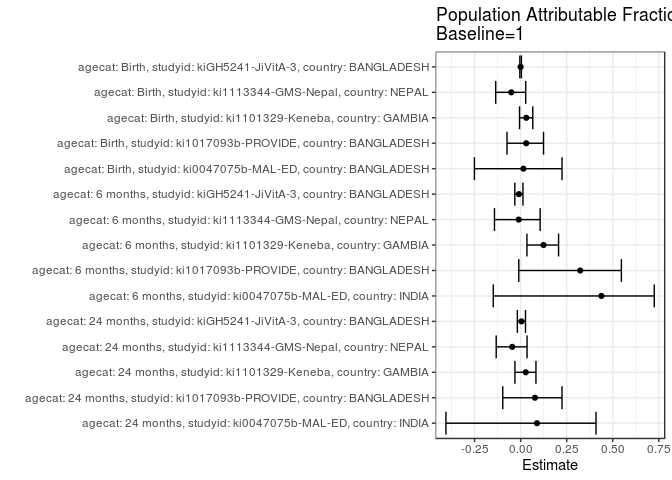

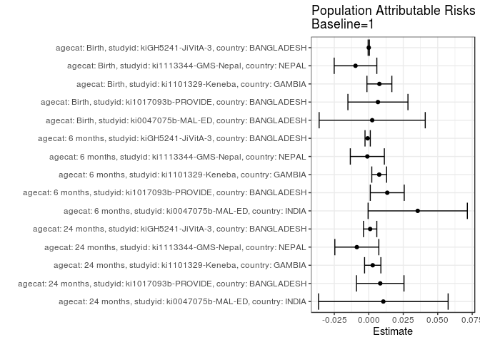

## Results Table

### Parameter: TSM

| agecat | studyid | country | intervention_level | baseline_level | estimate | ci_lower | ci_upper |
| --- | --- | --- | --- | --- | --- | --- | --- |
| Birth | ki0047075b-MAL-ED | BANGLADESH | 1 | NA | 0.1608858 | 0.0972984 | 0.2244732 |
| Birth | ki0047075b-MAL-ED | BANGLADESH | 0 | NA | 0.1746256 | 0.0876145 | 0.2616366 |
| Birth | ki1017093b-PROVIDE | BANGLADESH | 1 | NA | 0.2132756 | 0.1724668 | 0.2540844 |
| Birth | ki1017093b-PROVIDE | BANGLADESH | 0 | NA | 0.2379228 | 0.1702355 | 0.3056101 |
| Birth | ki1101329-Keneba | GAMBIA | 1 | NA | 0.2434602 | 0.2185677 | 0.2683527 |
| Birth | ki1101329-Keneba | GAMBIA | 0 | NA | 0.3099439 | 0.2361095 | 0.3837784 |
| Birth | ki1113344-GMS-Nepal | NEPAL | 1 | NA | 0.1991907 | 0.1574496 | 0.2409319 |
| Birth | ki1113344-GMS-Nepal | NEPAL | 0 | NA | 0.1508489 | 0.0690692 | 0.2326286 |
| Birth | kiGH5241-JiVitA-3 | BANGLADESH | 1 | NA | 0.1107784 | 0.1043645 | 0.1171922 |
| Birth | kiGH5241-JiVitA-3 | BANGLADESH | 0 | NA | 0.1111820 | 0.1035391 | 0.1188249 |
| 6 months | ki0047075b-MAL-ED | INDIA | 1 | NA | 0.0454545 | 0.0064356 | 0.0844735 |
| 6 months | ki0047075b-MAL-ED | INDIA | 0 | NA | 0.1200000 | 0.0561565 | 0.1838435 |
| 6 months | ki1017093b-PROVIDE | BANGLADESH | 1 | NA | 0.0280447 | 0.0123801 | 0.0437094 |
| 6 months | ki1017093b-PROVIDE | BANGLADESH | 0 | NA | 0.0736674 | 0.0344485 | 0.1128863 |
| 6 months | ki1101329-Keneba | GAMBIA | 1 | NA | 0.0532847 | 0.0420643 | 0.0645051 |
| 6 months | ki1101329-Keneba | GAMBIA | 0 | NA | 0.1178552 | 0.0743671 | 0.1613432 |
| 6 months | ki1113344-GMS-Nepal | NEPAL | 1 | NA | 0.1008174 | 0.0699785 | 0.1316564 |
| 6 months | ki1113344-GMS-Nepal | NEPAL | 0 | NA | 0.0945946 | 0.0278402 | 0.1613490 |
| 6 months | kiGH5241-JiVitA-3 | BANGLADESH | 1 | NA | 0.0876997 | 0.0810066 | 0.0943927 |
| 6 months | kiGH5241-JiVitA-3 | BANGLADESH | 0 | NA | 0.0787579 | 0.0579238 | 0.0995920 |
| 24 months | ki0047075b-MAL-ED | INDIA | 1 | NA | 0.1082545 | 0.0453945 | 0.1711146 |
| 24 months | ki0047075b-MAL-ED | INDIA | 0 | NA | 0.1338012 | 0.0654482 | 0.2021542 |
| 24 months | ki1017093b-PROVIDE | BANGLADESH | 1 | NA | 0.0987641 | 0.0697766 | 0.1277515 |
| 24 months | ki1017093b-PROVIDE | BANGLADESH | 0 | NA | 0.1264039 | 0.0757710 | 0.1770368 |
| 24 months | ki1101329-Keneba | GAMBIA | 1 | NA | 0.1005759 | 0.0840496 | 0.1171023 |
| 24 months | ki1101329-Keneba | GAMBIA | 0 | NA | 0.1300515 | 0.0734031 | 0.1866999 |
| 24 months | ki1113344-GMS-Nepal | NEPAL | 1 | NA | 0.1987578 | 0.1551132 | 0.2424023 |
| 24 months | ki1113344-GMS-Nepal | NEPAL | 0 | NA | 0.1451613 | 0.0573630 | 0.2329596 |
| 24 months | kiGH5241-JiVitA-3 | BANGLADESH | 1 | NA | 0.2177051 | 0.2034371 | 0.2319731 |
| 24 months | kiGH5241-JiVitA-3 | BANGLADESH | 0 | NA | 0.2294368 | 0.1735209 | 0.2853527 |

### Parameter: E(Y)

| agecat | studyid | country | intervention_level | baseline_level | estimate | ci_lower | ci_upper |
| --- | --- | --- | --- | --- | --- | --- | --- |
| Birth | ki0047075b-MAL-ED | BANGLADESH | NA | NA | 0.1633663 | 0.1122571 | 0.2144755 |
| Birth | ki1017093b-PROVIDE | BANGLADESH | NA | NA | 0.2199248 | 0.1846953 | 0.2551543 |
| Birth | ki1101329-Keneba | GAMBIA | NA | NA | 0.2511700 | 0.2274208 | 0.2749193 |
| Birth | ki1113344-GMS-Nepal | NEPAL | NA | NA | 0.1895735 | 0.1521320 | 0.2270149 |
| Birth | kiGH5241-JiVitA-3 | BANGLADESH | NA | NA | 0.1107768 | 0.1043978 | 0.1171557 |
| 6 months | ki0047075b-MAL-ED | INDIA | NA | NA | 0.0809524 | 0.0439731 | 0.1179317 |
| 6 months | ki1017093b-PROVIDE | BANGLADESH | NA | NA | 0.0414594 | 0.0255348 | 0.0573839 |
| 6 months | ki1101329-Keneba | GAMBIA | NA | NA | 0.0608496 | 0.0496205 | 0.0720787 |
| 6 months | ki1113344-GMS-Nepal | NEPAL | NA | NA | 0.0997732 | 0.0717702 | 0.1277763 |
| 6 months | kiGH5241-JiVitA-3 | BANGLADESH | NA | NA | 0.0868958 | 0.0805887 | 0.0932029 |
| 24 months | ki0047075b-MAL-ED | INDIA | NA | NA | 0.1188119 | 0.0740803 | 0.1635435 |
| 24 months | ki1017093b-PROVIDE | BANGLADESH | NA | NA | 0.1070812 | 0.0818727 | 0.1322897 |
| 24 months | ki1101329-Keneba | GAMBIA | NA | NA | 0.1034483 | 0.0876083 | 0.1192882 |
| 24 months | ki1113344-GMS-Nepal | NEPAL | NA | NA | 0.1901042 | 0.1508072 | 0.2294011 |
| 24 months | kiGH5241-JiVitA-3 | BANGLADESH | NA | NA | 0.2187047 | 0.2046312 | 0.2327783 |

### Parameter: RR

| agecat | studyid | country | intervention_level | baseline_level | estimate | ci_lower | ci_upper |
| --- | --- | --- | --- | --- | --- | --- | --- |
| Birth | ki0047075b-MAL-ED | BANGLADESH | 1 | 1 | 1.0000000 | 1.0000000 | 1.000000 |
| Birth | ki0047075b-MAL-ED | BANGLADESH | 0 | 1 | 1.0854007 | 0.5735743 | 2.053953 |
| Birth | ki1017093b-PROVIDE | BANGLADESH | 1 | 1 | 1.0000000 | 1.0000000 | 1.000000 |
| Birth | ki1017093b-PROVIDE | BANGLADESH | 0 | 1 | 1.1155652 | 0.7949960 | 1.565398 |
| Birth | ki1101329-Keneba | GAMBIA | 1 | 1 | 1.0000000 | 1.0000000 | 1.000000 |
| Birth | ki1101329-Keneba | GAMBIA | 0 | 1 | 1.2730784 | 0.9838143 | 1.647393 |
| Birth | ki1113344-GMS-Nepal | NEPAL | 1 | 1 | 1.0000000 | 1.0000000 | 1.000000 |
| Birth | ki1113344-GMS-Nepal | NEPAL | 0 | 1 | 0.7573090 | 0.4233091 | 1.354842 |
| Birth | kiGH5241-JiVitA-3 | BANGLADESH | 1 | 1 | 1.0000000 | 1.0000000 | 1.000000 |
| Birth | kiGH5241-JiVitA-3 | BANGLADESH | 0 | 1 | 1.0036436 | 0.9604022 | 1.048832 |
| 6 months | ki0047075b-MAL-ED | INDIA | 1 | 1 | 1.0000000 | 1.0000000 | 1.000000 |
| 6 months | ki0047075b-MAL-ED | INDIA | 0 | 1 | 2.6399999 | 0.9616175 | 7.247788 |
| 6 months | ki1017093b-PROVIDE | BANGLADESH | 1 | 1 | 1.0000000 | 1.0000000 | 1.000000 |
| 6 months | ki1017093b-PROVIDE | BANGLADESH | 0 | 1 | 2.6267797 | 1.2127565 | 5.689495 |
| 6 months | ki1101329-Keneba | GAMBIA | 1 | 1 | 1.0000000 | 1.0000000 | 1.000000 |
| 6 months | ki1101329-Keneba | GAMBIA | 0 | 1 | 2.2118007 | 1.4477120 | 3.379168 |
| 6 months | ki1113344-GMS-Nepal | NEPAL | 1 | 1 | 1.0000000 | 1.0000000 | 1.000000 |
| 6 months | ki1113344-GMS-Nepal | NEPAL | 0 | 1 | 0.9382761 | 0.4348109 | 2.024701 |
| 6 months | kiGH5241-JiVitA-3 | BANGLADESH | 1 | 1 | 1.0000000 | 1.0000000 | 1.000000 |
| 6 months | kiGH5241-JiVitA-3 | BANGLADESH | 0 | 1 | 0.8980410 | 0.6799827 | 1.186027 |
| 24 months | ki0047075b-MAL-ED | INDIA | 1 | 1 | 1.0000000 | 1.0000000 | 1.000000 |
| 24 months | ki0047075b-MAL-ED | INDIA | 0 | 1 | 1.2359870 | 0.5688412 | 2.685572 |
| 24 months | ki1017093b-PROVIDE | BANGLADESH | 1 | 1 | 1.0000000 | 1.0000000 | 1.000000 |
| 24 months | ki1017093b-PROVIDE | BANGLADESH | 0 | 1 | 1.2798568 | 0.7787769 | 2.103341 |
| 24 months | ki1101329-Keneba | GAMBIA | 1 | 1 | 1.0000000 | 1.0000000 | 1.000000 |
| 24 months | ki1101329-Keneba | GAMBIA | 0 | 1 | 1.2930677 | 0.8118823 | 2.059442 |
| 24 months | ki1113344-GMS-Nepal | NEPAL | 1 | 1 | 1.0000000 | 1.0000000 | 1.000000 |
| 24 months | ki1113344-GMS-Nepal | NEPAL | 0 | 1 | 0.7303427 | 0.3837740 | 1.389882 |
| 24 months | kiGH5241-JiVitA-3 | BANGLADESH | 1 | 1 | 1.0000000 | 1.0000000 | 1.000000 |
| 24 months | kiGH5241-JiVitA-3 | BANGLADESH | 0 | 1 | 1.0538881 | 0.8211513 | 1.352589 |

### Parameter: PAR

| agecat | studyid | country | intervention_level | baseline_level | estimate | ci_lower | ci_upper |
| --- | --- | --- | --- | --- | --- | --- | --- |
| Birth | ki0047075b-MAL-ED | BANGLADESH | 1 | NA | 0.0024805 | -0.0359932 | 0.0409543 |
| Birth | ki1017093b-PROVIDE | BANGLADESH | 1 | NA | 0.0066492 | -0.0151226 | 0.0284211 |
| Birth | ki1101329-Keneba | GAMBIA | 1 | NA | 0.0077099 | -0.0013244 | 0.0167441 |
| Birth | ki1113344-GMS-Nepal | NEPAL | 1 | NA | -0.0096173 | -0.0250799 | 0.0058454 |
| Birth | kiGH5241-JiVitA-3 | BANGLADESH | 1 | NA | -0.0000016 | -0.0004684 | 0.0004652 |
| 6 months | ki0047075b-MAL-ED | INDIA | 1 | NA | 0.0354978 | -0.0004879 | 0.0714835 |
| 6 months | ki1017093b-PROVIDE | BANGLADESH | 1 | NA | 0.0134146 | 0.0011052 | 0.0257240 |
| 6 months | ki1101329-Keneba | GAMBIA | 1 | NA | 0.0075649 | 0.0021925 | 0.0129373 |
| 6 months | ki1113344-GMS-Nepal | NEPAL | 1 | NA | -0.0010442 | -0.0133851 | 0.0112967 |
| 6 months | kiGH5241-JiVitA-3 | BANGLADESH | 1 | NA | -0.0008039 | -0.0027221 | 0.0011143 |
| 24 months | ki0047075b-MAL-ED | INDIA | 1 | NA | 0.0105573 | -0.0364293 | 0.0575440 |
| 24 months | ki1017093b-PROVIDE | BANGLADESH | 1 | NA | 0.0083171 | -0.0089135 | 0.0255477 |
| 24 months | ki1101329-Keneba | GAMBIA | 1 | NA | 0.0028723 | -0.0030427 | 0.0087874 |
| 24 months | ki1113344-GMS-Nepal | NEPAL | 1 | NA | -0.0086536 | -0.0246070 | 0.0072998 |
| 24 months | kiGH5241-JiVitA-3 | BANGLADESH | 1 | NA | 0.0009996 | -0.0038309 | 0.0058302 |

### Parameter: PAF

| agecat | studyid | country | intervention_level | baseline_level | estimate | ci_lower | ci_upper |
| --- | --- | --- | --- | --- | --- | --- | --- |
| Birth | ki0047075b-MAL-ED | BANGLADESH | 1 | NA | 0.0151839 | -0.2508520 | 0.2246384 |
| Birth | ki1017093b-PROVIDE | BANGLADESH | 1 | NA | 0.0302341 | -0.0739490 | 0.1243106 |
| Birth | ki1101329-Keneba | GAMBIA | 1 | NA | 0.0306958 | -0.0058876 | 0.0659486 |
| Birth | ki1113344-GMS-Nepal | NEPAL | 1 | NA | -0.0507311 | -0.1352628 | 0.0275064 |
| Birth | kiGH5241-JiVitA-3 | BANGLADESH | 1 | NA | -0.0000146 | -0.0042374 | 0.0041904 |
| 6 months | ki0047075b-MAL-ED | INDIA | 1 | NA | 0.4385027 | -0.1484993 | 0.7254859 |
| 6 months | ki1017093b-PROVIDE | BANGLADESH | 1 | NA | 0.3235607 | -0.0100042 | 0.5469621 |
| 6 months | ki1101329-Keneba | GAMBIA | 1 | NA | 0.1243211 | 0.0342797 | 0.2059673 |
| 6 months | ki1113344-GMS-Nepal | NEPAL | 1 | NA | -0.0104657 | -0.1420133 | 0.1059291 |
| 6 months | kiGH5241-JiVitA-3 | BANGLADESH | 1 | NA | -0.0092509 | -0.0315413 | 0.0125578 |
| 24 months | ki0047075b-MAL-ED | INDIA | 1 | NA | 0.0888577 | -0.4053518 | 0.4092723 |
| 24 months | ki1017093b-PROVIDE | BANGLADESH | 1 | NA | 0.0776710 | -0.0970573 | 0.2245703 |
| 24 months | ki1101329-Keneba | GAMBIA | 1 | NA | 0.0277660 | -0.0309880 | 0.0831717 |
| 24 months | ki1113344-GMS-Nepal | NEPAL | 1 | NA | -0.0455203 | -0.1326078 | 0.0348709 |
| 24 months | kiGH5241-JiVitA-3 | BANGLADESH | 1 | NA | 0.0045707 | -0.0177258 | 0.0263788 |